# Linear Regression

## Creating and Training the Model

```python
from sklearn.linear_model import LinearRegression
```

```python
lm = LinearRegression()
```

```python
lm.fit(X_train,y_train)
```

```
LinearRegression()
```

## Find Model Coefficients

Let's evaluate the model by checking out it's coefficients and how we can interpret them.

```python
# print the intercept(b0)
print(lm.intercept_)
```

```
1228450.3183806066
```

```python
# print the coefficients(b1, b2, ...)
print(lm.coef_)
```

```
[227623.4635687  160615.53988611 121847.23967883   2752.11164641
 151227.42361628]
```

# Prediction

```python
predictions = lm.predict(X_test)
```

```python
#y hat
predictions
```

```
array([1260960.70581765,  827588.7554468 , 1742421.24257407, ...,
        372191.4061308 , 1365217.15136989, 1914519.54191649])
```

# مقایسه ایگرگ های تست و مقدار پیش بینی شده

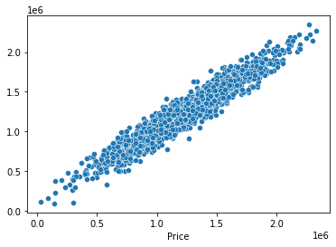

```python
sns.scatterplot(x=y_test, y=predictions)
```

**Residual Histogram**

```python
residual= y_test-predictions
```

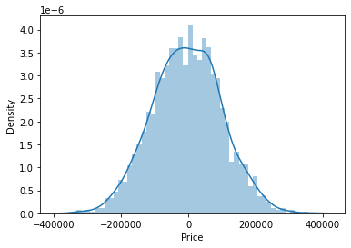

```python
sns.distplot(residual,bins=50);
```

## Regression Evaluation Metrics

Here are three common evaluation metrics for regression problems:

**Mean Absolute Error** (MAE) is the mean of the absolute value of the errors:

$$\frac 1n\sum_{i=1}^n|y_i-\hat{y}_i|$$

**Mean Squared Error** (MSE) is the mean of the squared errors:

$$\frac 1n\sum_{i=1}^n(y_i-\hat{y}_i)^2$$

**Root Mean Squared Error** (RMSE) is the square root of the mean of the squared errors:

$$\sqrt{\frac 1n\sum_{i=1}^n(y_i-\hat{y}_i)^2}$$

Comparing these metrics:

- **MAE** is the easiest to understand, because it's the average error.
- **MSE** is more popular than MAE, because MSE "punishes" larger errors, which tends to be useful in the real world.
- **RMSE** is even more popular than MSE, because RMSE is interpretable in the "y" units.

All of these are **loss functions**, because we want to minimize them.

```python
from sklearn import metrics
```

```python
print('MAE:', metrics.mean_absolute_error(y_test, predictions))
print('MSE:', metrics.mean_squared_error(y_test, predictions))
print('RMSE:', np.sqrt(metrics.mean_squared_error(y_test, predictions)))
print('R2:', np.sqrt(metrics.r2_score(y_test, predictions)))
```

```
MAE: 82288.222507218
MSE: 10460958905.775793
RMSE: 102278.8292159027
R2: 0.9579574108373385
```

Congrats!